# Lab2

Do all the objects have the same length? Yes

Are there missing values, i.e. NA, in any of the objects? No

Class of objects player is “character” team is “factor” points(all) are “integer” position is “character” salary is “numeric”

How do you know if any of the loaded objects is a vector? is.vector()

How do you know that a given vector is of a certain data type? use typeof

players in position Center, of Warriors (GSW) “Damian Jones” “David West”  
“JaVale McGee” “Kevon Looney” “Zaza Pachulia”

players of both GSW (warriors) and LAL (lakers) [1] “Andre Iguodala”  
[2] “Damian Jones”  
[3] “David West”  
[4] “Draymond Green”  
[5] “Ian Clark”  
[6] “James Michael McAdoo” [7] “JaVale McGee”  
[8] “Kevin Durant”  
[9] “Kevon Looney”  
[10] “Klay Thompson”  
[11] “Matt Barnes”  
[12] “Patrick McCaw”  
[13] “Shaun Livingston”  
[14] “Stephen Curry”  
[15] “Zaza Pachulia”  
[16] “Brandon Ingram”  
[17] “Corey Brewer”  
[18] “D’Angelo Russell”  
[19] “David Nwaba”  
[20] “Ivica Zubac”  
[21] “Jordan Clarkson”  
[22] “Julius Randle”  
[23] “Larry Nance Jr.”  
[24] “Luol Deng”  
[25] “Metta World Peace”  
[26] “Nick Young”  
[27] “Tarik Black”  
[28] “Thomas Robinson”  
[29] “Timofey Mozgov”  
[30] “Tyler Ennis

players in positions Shooting Guard and Point Guards, of Lakers (LAL) [1] “D’Angelo Russell” “David Nwaba”  
[3] “Jordan Clarkson” “Nick Young”  
[5] “Tyler Ennis”

subset Small Forwards of GSW and LAL [1] “Andre Iguodala” “Kevin Durant”  
[3] “Matt Barnes” “Brandon Ingram”  
[5] “Corey Brewer” “Luol Deng”  
[7] “Metta World Peace”

name of the player with largest salary “LeBron James”

name of the player with smallest salary “Edy Tavares”

name of the player with largest number of scored points “Russell Westbrook”

salary of the player with largest number of points 26540100

largest salary of all Centers 26540100

team of the player with the largest number of scored points OKC

name of the player with the largest number of 3-pointers “Stephen Curry”

```r
load('nba2017-salary-points.RData')
length(player)
```

```
## [1] 441
```

```r
sum(is.na(position))
```

```
## [1] 0
```

```r
four <- head(player, n = 4)
four[1]
```

```
## [1] "Al Horford"
```

```r
four[-1]
```

```
## [1] "Amir Johnson"      "Avery Bradley"     "Demetrius Jackson"
```

```r
four[-c(1,2,3)]
```

```
## [1] "Demetrius Jackson"
```

```r
four[5]
```

```
## [1] NA
```

```r
four[c(1,2,2,3,3,3)]
```

```
## [1] "Al Horford"    "Amir Johnson"  "Amir Johnson"  "Avery Bradley"
## [5] "Avery Bradley" "Avery Bradley"
```

```r
even_players <- player[seq(2,length(player), 2)]
odd_sal <- salary[seq(1,length(salary), 2)]
team5 <- team[seq(5, length(team), 5)]
score10 <- points[seq(5, length(team), 5)]
rev_team <- team[seq(length(team)-1,2, -2)]

player[team == "GSW" & position == "C"]
```

```
## [1] "Damian Jones"  "David West"    "JaVale McGee"  "Kevon Looney"
## [5] "Zaza Pachulia"
```

```r
player[salary == max(salary)]
```

```
## [1] "LeBron James"
```

```r
max(salary[position == "C"])
```

```
## [1] 26540100
```

```r
warriors_player <- player[team == "GSW"]
warriors_salary <- salary[team == "GSW"]
warriors_points <- points[team == "GSW"]
names(warriors_salary) <- warriors_player
warriors_salary[c("Stephen Curry", "Kevin Durant")]
```

```
## Stephen Curry  Kevin Durant
##      12112359      26540100
```

```r
warriors_salary["Andre Iguodala"]
```

```
## Andre Iguodala
##       11131368
```

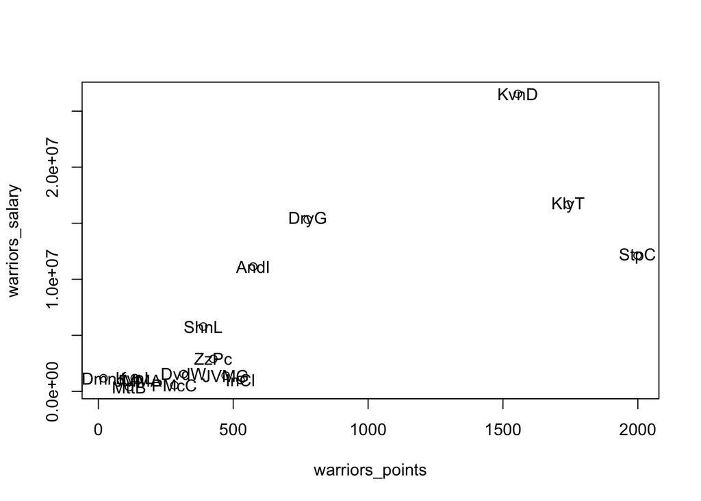

```r
plot.new()
plot(warriors_points, warriors_salary)
text(warriors_points, warriors_salary, labels = abbreviate(warriors_player))
```

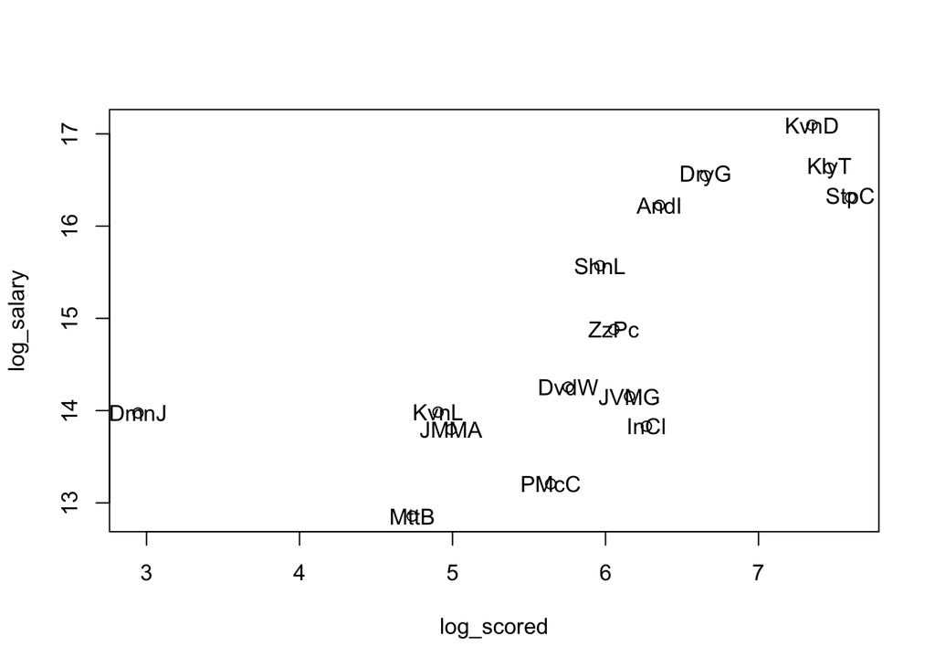

```r
log_scored <- log(warriors_points)
log_salary <- log(warriors_salary)
plot.new()
plot(log_scored, log_salary)
text(log_scored, log_salary, labels = abbreviate(warriors_player))
```

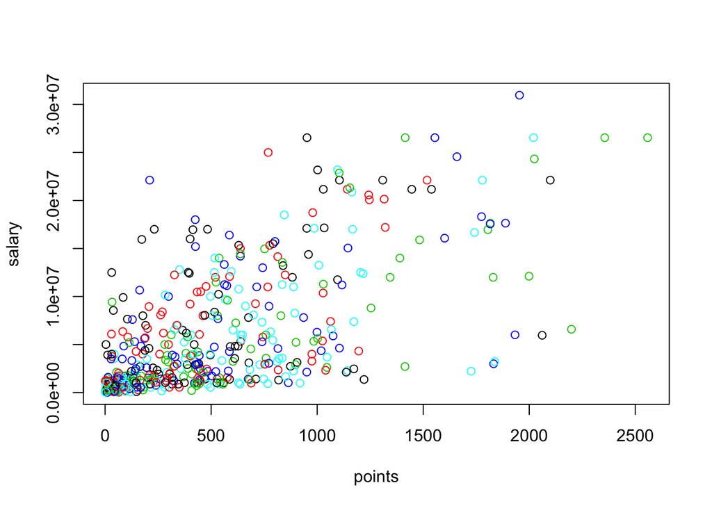

```r
plot.new()
salary_millions <- salary/10000000
scored_points = 3*points3 + 2*points2 + points1

position_fac <- factor(position)
plot(points, salary, col=position_fac)
```